# Manual Git

#### `git merge`

Para notar las diferencias, en la rama de desarrollo *(dev)* creamos un archivo que sólo existe en esa rama, y después lo modificamos. Podemos notar que los commits que nos aparecen están sobre el HEAD que es *dev* porque estamos trabajando sobre esa rama, y que tiene dos commits más que los commits que tenía *master*

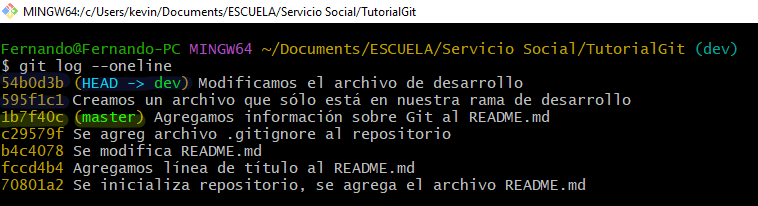

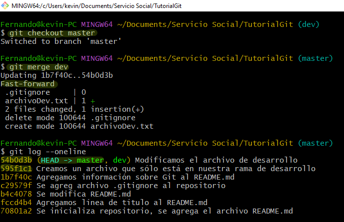

##### *Fast-Forward*

Un avance rápido (*fast-forward*) es un tipo especial de fusión en el que tienes una revisión y estás “fusionando” los cambios de la rama de desarrollo que resultan ser descendientes de lo que tienes en la rama por fusionar, es decir, el *fast-forward* pasa en situaciones donde exista un proceso lineal desde el extremo de la rama actual y que se extienda hasta la rama de destino. En tal caso, no se realiza un commit del merge, sino que Git simplemente actualiza tu rama para que apunte a la misma revisión que la rama que estás fusionando.

##### *Auto-Merging*

En los casos en que los cambios entren en conflicto, es decir, cuando Git no puede resolver automáticamente las diferencias en el código entre dos commits. Es posible que se requiera una intervención manual para completar la fusión.

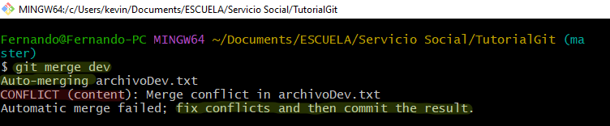

Lo que pasó en este caso que las mismas líneas del mismo archivo fueron modificadas en la rama de desarrollo *dev*. Git nos muestra qué hay en el *HEAD* (en este caso la rama master) y qué hay en la rama *dev*, pero Git nos pide hacer manualmente el merge a base de eligir cuál es la versión que formará parte del proyecto y posteriormente hacer un *commit* del merge.

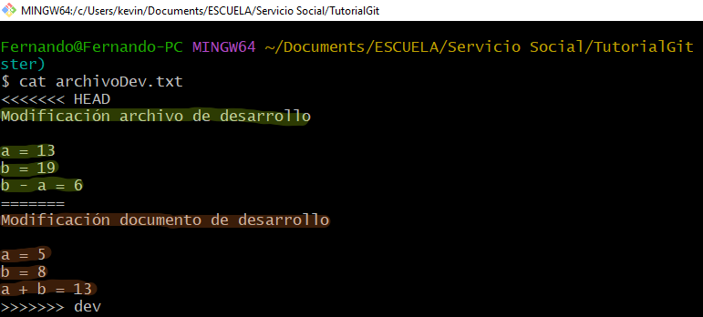

Modificamos el archivo en cuestión con los cambios que quedarán en el proyecto y hacemos el commit del merge.

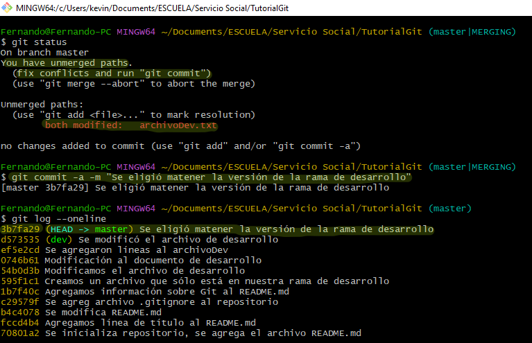

#### `git reset`

Para restablecer el repositorio en caso de necesitarlo podemos hacerlo con `git reset --hard` El modificador `--hard` restablece tanto el *Staging Area* como el *Working Directory*. Esto restablece correctamente el repositorio al estado original. Después de escribir esto comando, HEAD se mueve (rebobina) a la versión que deseamos.

Supongamos que la versión de nuestro ejemplo a la que le hicimos commit al final no es la que queríamos. Vamos a deshacer ese commit. Tomamos el código (color azul) del commit al que queremos regresar, y lo escribimos con el comando `reset`, vemos que al siguiente `git log` ya no tenemos el commit del merge anterior .

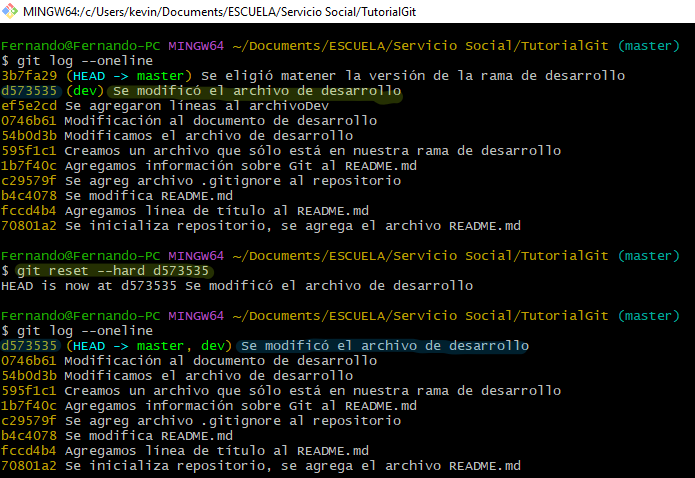

# GitHub

[figure not shown]

## ¿Qué es GitHub?

[GitHub](https://github.com/) el sitio web de alojamiento de proyectos de Git. Aprovecha la arquitectura distribuida de Git, pero ofrece funciones adicionales de administración y colaboración de proyectos, como el seguimiento de problemas y gestión básica de colaboración. Las funciones de codificación social de GitHub la han convertido en una plataforma popular para alojar y compartir código.

## Primeros pasos con GitHub

Lo primero que debemos hacer para trabajar con [GitHub](https://github.com/) es crear una cuenta. Para esto será importante que el correo sea el mismo con hiciste la configuración inicial de Git.

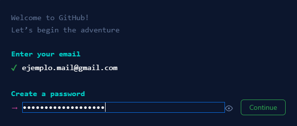

## Empezando con GitHub

Una vez creada tu cuenta es hora de ajolar tus repositorios locales en repositorios remotos. Lo primero que vas a encontrar es una página cómo esta, y para alojar tus repositorios locales tendrás la opción seleccionar en el **+** de la esquina superior deracha o seleccionar el apartado **repositories.**

[figure not shown]

Cualquier opción que elijas tendrá el apartado *New Repository*, y después de seleccionarlo veremos la siguiente página:

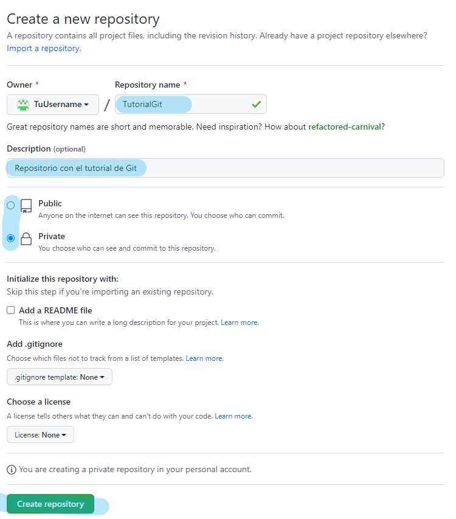

Aquí vamos a escribir el nombre del repositorio (opción obligatoria) y lo ideal es que coincida con el nombre de tu repositorio local. Además vamos a poder agregar una breve descripción del repositorio en caso de ser necesario. Vamos a elegir la visibilidad de nuestro repositorio (*public, private*), y posteriormente podemos dar click en *Create repository*

[figure not shown]

Para poder enlazar nuestro repositorio local (computadora) con el remoto (GitHub), hace falta copiar la liga que nos crea GitHub del repositorio remoto.

### Comandos comunes de trabajo en GitHub

#### `git remote`

Para enlazar nuestro repositorio local con el remoto es necesario usar el comando `git remote add origin https://github.com/TuUsername/nombreRep.git` donde `origin` es el nombre del enlace (por lo convención se usa la palabra *origin* aunque puedes poner otro identificador).

Con `git remote -v` podemos ver que el enlace está listo, es decir, en caso de que el comando no imprima nada, entonces no hay ningún enlace. También es posible desenlazar los repositorios, con `git remote remove origin`.

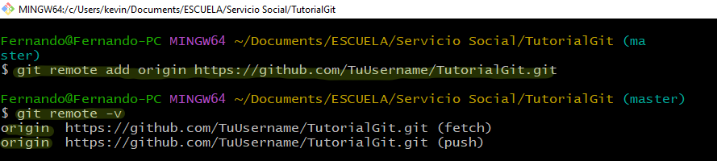

Sin embargo, aunque los repositorios ya estén enlazados aún no será posible ver el contenido del repositorio local en GitHub hasta que exportemos el repositorio.

#### `git push`

Para exportar nuestro repositorio por primera vez usamos el comando `git push -u origin master`, con este comando estamos pasando el historial de versiones de nuestra Master branch a GitHub, y será la rama que siempre mostrará como default, sin embargo, también podemos hacer `git push` a cada rama que necesitemos en GitHub con `git push -u origin rama` donde rama será la rama que quieres exportar.

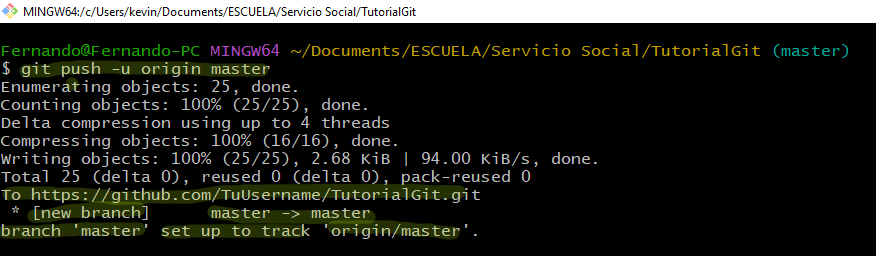

Cuando hacemos push al proyecto por primera vez se crea una referencia con el nombre del enlance y el nombre de la rama, en este caso *origin/master*.

Cuando actualizamos la página de GitHub, vamos a ver que nuestro repositorio ya está actualizado. GitHUb nos muestra de una forma más sencilla y visual (sin usar los comandos de Git), el número de ramas y la rama HEAD, donde podemos ver el número total de commits de la rama y la descripción detallada de cada uno cuando le damos click.

*En caso de haber un archivo README.md, GitHUb ya nos muestra el archivo renderizado.*

[figure not shown]

En gerenal, cuando queramos enviar cambios a GitHub basta con usar el mismo comando con la rama que queramos enviar, así mantendremos nuestro repositorio remoto actualizado con los cambios que hagamos en nuestro repositorio local.

**Nota**: *No puedes enviar cambios al repositorio remoto a menos que tu repositorio local esté sincronizado con el repositorio remoto. Para eso es necesario primero actualizar tu repositorio local si hubo cambios en el repositorio remoto (generalmente con el trabajo colaborativo).*

- `git push -u origin --delete rama`: Borra la rama del repositorio remoto.
- `git push –u origin –f`: Fuerza los cambios al repositorio remoto por ejemplo cuando eliminamos un commit del repositorio local, despues de haber usado `git reset` para eliminar un commit.

## Trabajo colaborativo con GitHuB

Se puede trabajar en colaboracón directamente sobre un repositorio ya creado de algún usuario con “add people”.

Una vez que elijamos la opción de agregar colaborador, sólo será necesario saber el correo o username del colaborador al que queremos invitar al proyecto. Le llegará un correo con la invitación y una vez que la acepte el repositorio está listo para que se trabaje en equipo. Es necesario tener en cuenta que esta opción de trabajo funciona cuando sólo se planea colaborar en un repositorio.

[figure not shown]

Sin embargo, otra forma de trabajar en equipo es por medio de una organización, dentro de esta organización se pueden crear los repositorios que se necesiten y todos los colaboradores tienen acceso a todos los repositorios. Viéndolo de otra forma es como tener una carpeta con todos los distintos proyectos del mismo equipo de trabajo.

Para crear una organización sólo es necesario abrir la ventana de opciones **+** en la esquina superior derecha y seleccionar *new organization*.

Escribe el nombre de la organización, y tu correo de GitHUb. Posteriormente, por medio del username o correo de tu colaborador (o colaboradores) puedes crear las invitaciones para participar en la organización.

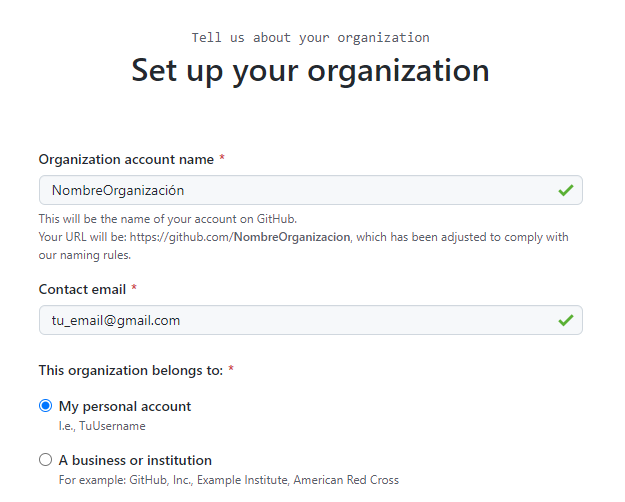

### Comandos comunes de trabajo colaborativo en GitHub

#### `git clone`

Cuando empiezas un a colaborar en un trabajo es necesario crear una copia en tu local del repositorio que ya ha sido creado por quien comenzó el trabajo colaborativo. Así podrás trabajar directamente en tu copia local del repositorio y enviar las modificaciones que hayas hecho al repositorio remoto de GitHub. Para crear la copia local es necesario copiar la liga *https* del repositorio remoto que nos proporciona GitHub. Ahora será necesario situarte en un directorio de trabajo donde vas a alojar tu copia local del repositorio remoto. Abrimos Git BASH y escribimos el comando `git clone` seguido del la liga *https* del repositorio remoto.

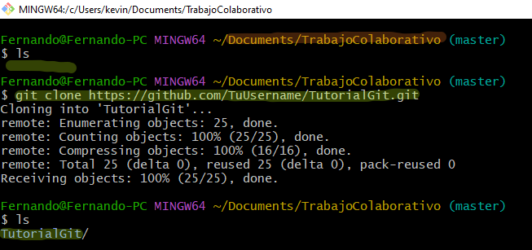

#### `git fetch`

Cuando existen cambios en el repositorio remoto, ya sea por algún colaborador o por nosotros mismo directamente en el repositorio remoto, es necesario tener los cambios en nuestro repositorio local. Para importar los cambios se hace un proceso equivalente al de `git push`.

[figure not shown]

El comando `git fetch` recupera archivos de un repositorio e incorpora esos archivos a su repositorio. Específicamente, git fetch recupera referencias, lo que significa ramas o etiquetas (tags), a través del fetch_head, el cual es una referencia a la rama remota que acabas de buscar, por lo general *origin/nombre_de_la_rama*.

Cuando `git fetch origin` ya recuperó la referencia de la rama, el siguiente paso es fusionarla con nuestro repositorio local. Es decir, usamos el comando `git merge origin/master`.

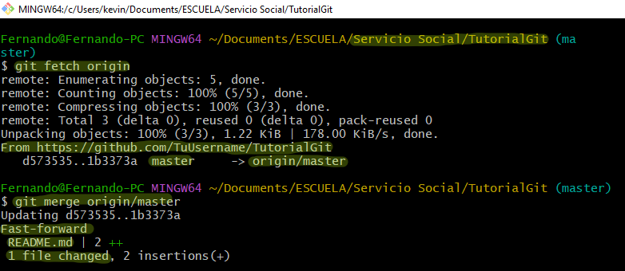

De esta forma ya agregamos los cambios de algún colaborador a nuestro repositorio local. Una forma más sencilla de importar los cambios es usando el comando `git pull`.

#### `git pull`

Rcordemos que la rama principal *Master branch* debe ser una rama estable, por lo que es importante tener la rama de desarrollo que sería una rama de pruebas antes de fusionar los cambios a la rama master. Sin embargo, en el trabajo colaborativo es muy buena práctica tener una rama de desarrollo por cada colaborador, y una vez que los cambios sean funcionales y se esté de acuerdo con las modificaciones de cada uno, lo ideal es integrar los cambios a la rama de desarrollo, para finalizar incorporandolos a la rama master completamente estable.

En este caso hay tres ramas creadas, la principal *master* que es el HEAD por el momento, la rama de desarrollo *dev*, y tu rama *personal*.

[figure not shown]

Nuestro colaborador creará su rama y empezara su desarrollo sobre la misma. Cuando sus cambios estén listos va a mandar esos cambios a GitHub a través de su rama.

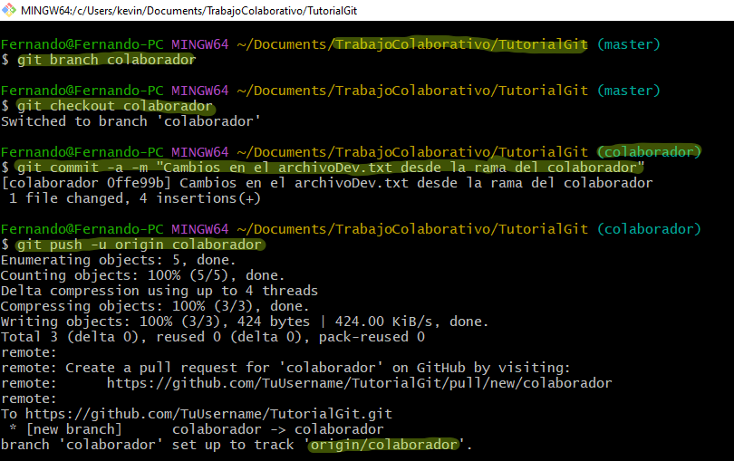

Actualizando la página de GitHub, podemos ver que ya está arriba la rama del colaborador, junto con los commits que hizo.

[figure not shown]

Ahora nosotros podemos importar los cambios del colaborador haciendo `git fetch` y posteriormente `git merge` o simplemente usando el comando `git pull` que se encarga de comprimir ambos comandos, es decir, `git pull` hace un `git fetch` y un `git merge` internamente.

Al usar `git pull` pueden pasar dos casos: un mensaje de salida enlistada, o un archivo de texto abierto en el editor predeterminado de Git. El primer elemento se conoce como *clean merge* con un mensaje de confirmación automática. El segundo elemento es un *clean merge* con un mensaje de confirmación no automática.

La siguiente lista es el clean merge con un mensaje de confirmación automática.

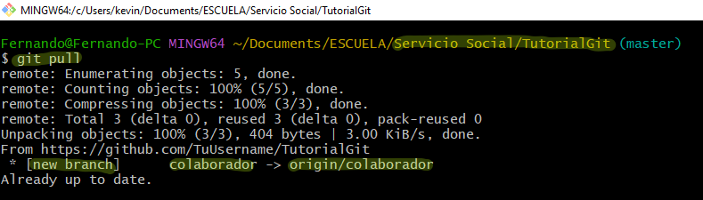

En este caso `git pull` ya realizó el `git merge` y ahora te pide que escribas un mensaje de confirmación. Pero no te preocupes, Git proporciona un mensaje predeterminado, `git pull` ejecutará `git commit` por ti una vez que salgas del editor. Para salir usa `:q`

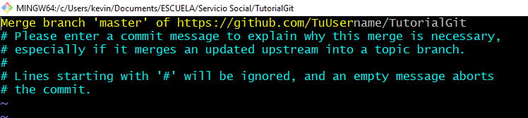

**Notas**:

- Cuando trabajamos en equipo, los colaboradores harán cambios en su repositorio local y después actualizaran el repositorio remoto. Por eso es necesario hacer `git pull`, o `git fetch` -> `git merge` para tener los cambios del repositorio remoto en nuestro repositorio local, después ya podemos subir nuestros cambios al repositorio remoto.
- Hay que tomar en cuenta que habrá veces que modifiquemos las mismas líneas de código que algún colaborador, por lo que será necesario decidir manualmente cuál quedará al final.